Submitter Details:  
Yarden Dahan, 208730523  
My Kaggle Link

# Notebook settings,installations

```python
# update plotly and pandas_profiling version
# !pip install --upgrade plotly
!pip install --upgrade pandas_profiling
```

# Importing

```python
# import numpy, matplotlib, etc.
import numpy as np
import pandas as pd
import seaborn as sns
import plotly.express as px
import matplotlib.pyplot as plt
import math
from numpy import sqrt
# sklearn imports
from sklearn import metrics
from sklearn import pipeline
from sklearn import linear_model
from sklearn import preprocessing
from sklearn import model_selection
from sklearn.pipeline import make_pipeline
from sklearn.model_selection import train_test_split

from sklearn import compose
from tqdm.auto import tqdm

from sklearn.preprocessing import OneHotEncoder
from sklearn.preprocessing import OrdinalEncoder

from sklearn.linear_model import LinearRegression
from sklearn.metrics import mean_absolute_error
from sklearn.linear_model import SGDRegressor



#Scalers
from sklearn.preprocessing import MinMaxScaler
from sklearn.preprocessing import minmax_scale
# from sklearn.preprocessing import MaxAbsScaler
from sklearn.preprocessing import StandardScaler
from sklearn.preprocessing import RobustScaler
from sklearn.preprocessing import Normalizer
# from sklearn.preprocessing import QuantileTransformer
# from sklearn.preprocessing import PowerTransformer
# use column transformer to insert different transformers for each column
from sklearn.compose import ColumnTransformer
#eda
from pandas_profiling import ProfileReport
#Feature selection
from sklearn.feature_selection import RFECV
from sklearn.model_selection import RepeatedKFold
#polynomial degree
from sklearn.preprocessing import PolynomialFeatures
#Regularization
from sklearn.model_selection import RandomizedSearchCV
from scipy.stats import uniform
import plotly.graph_objects as go
import os
# for dirname, _, filenames in os.walk('/kaggle/input'):
#     for filename in filenames:
#         print(os.path.join(dirname, filename))


# You can write up to 20GB to the current directory (/kaggle/working/) that gets preserved as output when you create a version using "Save & Run All"
# You can also write temporary files to /kaggle/temp/, but they won't be saved outside of the current session
```

# **HOUSE-PRICES CHALLENGE**

[figure not shown]

# 1. Introduction

Ask a home buyer to describe their dream house, and they probably won't begin with the height of the basement ceiling or the proximity to an east-west railroad.  
But this playground competition's dataset proves that much more influences price negotiations than the number of bedrooms or a white-picket fence.

With 79 explanatory variables describing (almost) every aspect of residential homes in Ames, Iowa, this competition challenges you to predict the final price of each home.

Practice Skills:

- Creative feature engineering
- Advanced regression techniques like random forest and gradient boosting

# 2. Data Exploration

## Data source:

The [Ames Housing dataset](http://jse.amstat.org/v19n3/decock.pdf) was compiled by Dean De Cock for use in data science education.  
The data set describing the sale of individual residential property in Ames, Iowa from 2006 to 2010. The data set contains 2930 observations and a large number of explanatory variables (23 nominal, 23 ordinal, 14 discrete, and 20 continuous) involved in assessing home values.

## A little to understand - Real Estate and Ames:

[figure not shown]

### **After examining the feature of apartment sales sites, it can be infer that the important features for the customer / buyer of an apartment:**

- Size in square feet
- Number of bedrooms
- number of bathrooms
- and of course the address of the property.
  - **Everyone knows that the most important thing when buying an apartment is the location! (Better location - more expensive price).**

### *Then specify the properties:*

[figure not shown]

- Whether there is a pool or not
- If the yard is designed
- If there is a fireplace

### *After this, the following features are generally noted:*

[figure not shown]

#### **A word or two about these features:**

- Single family:

[figure not shown]

  **"A single-family home is a free-standing residential building. Single-family homes are designed to be used as a single-dwelling unit, with one owner, no shared walls, and its own land."**  
  [For More Reading](https://www.rocketmortgage.com/learn/single-family-home)  
  [Other Types Of Homes](https://www.rocketmortgage.com/learn/types-of-houses)
- Bathrooms:

[figure not shown]

  [For More Reading-Bathrooms](https://www.badeloftusa.com/buying-guides/bathrooms/)

### Interior details:

[figure not shown]

### Property details:

[figure not shown]

### Construction details:

[figure not shown]

#### **A word or two about Architectural style:**

1-Story:

[figure not shown]

2-Story:

[figure not shown]

[More About - House Styles](https://www.bobvila.com/articles/339-know-your-house-styles/)

### Other:

[figure not shown]

Now that there is some understanding in the field - we can access the Ames Housing database with some prior knowledge in the field.  
From looking at the structure of the ad, and the order in which the features are displayed, it can be understood that each feature has a different importance to the customer / buyer of an apartment.  
After research on apartment pricing the hedonic method of pricing has repeatedly come up so I will detail it briefly:

### Hedonic Method:

The basic idea of hedonic price modeling is that neighborhood-specific and unit-specific characteristics help determine house prices.  
We will characterize the important variables for house pricing - size: the larger the house, the higher its value.  
In addition, the question arises how to price square feet, and why is it different from house to house?  
This leads us to the fact that pricing varies depending on location (better location better pricing)

[More About Economic Value](https://www.investopedia.com/terms/e/economic-value.asp)  
[More About Hedonic Pricing](https://www.investopedia.com/terms/h/hedonicpricing.asp)

### Location- its all about the Loaction:

What does a good location mean?  
Good location is also reflected in the ancillary services (eg good schools, etc.), accessibility to transportation (close to the train station, etc.), aesthetics and beauty (nice houses, trees in the streets, etc.).  
Among other things, high socio-economic status - in order to increase the value of apartments.  
Other things that are important in determining the prices of apartments - the number of rooms (especially - bedrooms, bathrooms and the condition of the kitchen), the age of the house (the year it was built) and the building materials are important.

### To sum up-

Factors influencing: property size, location, nearby services, number of rooms, building materials, age of the building, condition of the building.

**Now I can start analyzing all the data and start the challenge.**

# 3. Load Data

## Load Train & Test Dataframe:

**note: I will make the same changes on both groups. (I will make the changes to the test group just before submitting the challenge).**

```python
# data_train = pd.read_csv('../input/house-prices-advanced-regression-techniques/train.csv')
# print(data_train['Id'])
# Match the line to ID

#Load test
# df_test = pd.read_csv('../input/house-prices-advanced-regression-techniques/test.csv')
df_test = pd.read_csv('test.csv')
test_id =df_test['Id']
df_test = df_test.drop(['Id'],axis = 1)
# Load train
# df_train = pd.read_csv('../input/house-prices-advanced-regression-techniques/train.csv', index_col='Id')
df_train = pd.read_csv('train.csv', index_col='Id')
df_train.head()
```

| Id | MSSubClass | MSZoning | LotFrontage | LotArea | Street | Alley | LotShape | LandContour | Utilities | LotConfig | LandSlope | Neighborhood | Condition1 | Condition2 | BldgType | HouseStyle | OverallQual | OverallCond | YearBuilt | YearRemodAdd | RoofStyle | RoofMatl | Exterior1st | Exterior2nd | MasVnrType | MasVnrArea | ExterQual | ExterCond | Foundation | … |
| --- | --- | --- | --- | --- | --- | --- | --- | --- | --- | --- | --- | --- | --- | --- | --- | --- | --- | --- | --- | --- | --- | --- | --- | --- | --- | --- | --- | --- | --- | --- |
| 1 | 60 | RL | 65.0 | 8450 | Pave | NaN | Reg | Lvl | AllPub | Inside | Gtl | CollgCr | Norm | Norm | 1Fam | 2Story | 7 | 5 | 2003 | 2003 | Gable | CompShg | VinylSd | VinylSd | BrkFace | 196.0 | Gd | TA | PConc | … |
| 2 | 20 | RL | 80.0 | 9600 | Pave | NaN | Reg | Lvl | AllPub | FR2 | Gtl | Veenker | Feedr | Norm | 1Fam | 1Story | 6 | 8 | 1976 | 1976 | Gable | CompShg | MetalSd | MetalSd | None | 0.0 | TA | TA | CBlock | … |
| 3 | 60 | RL | 68.0 | 11250 | Pave | NaN | IR1 | Lvl | AllPub | Inside | Gtl | CollgCr | Norm | Norm | 1Fam | 2Story | 7 | 5 | 2001 | 2002 | Gable | CompShg | VinylSd | VinylSd | BrkFace | 162.0 | Gd | TA | PConc | … |
| 4 | 70 | RL | 60.0 | 9550 | Pave | NaN | IR1 | Lvl | AllPub | Corner | Gtl | Crawfor | Norm | Norm | 1Fam | 2Story | 7 | 5 | 1915 | 1970 | Gable | CompShg | Wd Sdng | Wd Shng | None | 0.0 | TA | TA | BrkTil | … |
| 5 | 60 | RL | 84.0 | 14260 | Pave | NaN | IR1 | Lvl | AllPub | FR2 | Gtl | NoRidge | Norm | Norm | 1Fam | 2Story | 8 | 5 | 2000 | 2000 | Gable | CompShg | VinylSd | VinylSd | BrkFace | 350.0 | Gd | TA | PConc | … |

```python
print(f' train shape = {df_train.shape}')
print("*"*50)
print(f' test shape = {df_test.shape}')
```

```
 train shape = (1460, 80)
 test shape = (1459, 79)
```

The training group has 80 columns and 1460 rows:  
79 Properties + Target Column (Sale Price).  
The test group has 79 columns and 1459 rows.

```python
# data_DSCR = open("../input/house-prices-advanced-regression-techniques/data_description.txt", "r")
data_DSCR = open("data_description.txt", "r")
print(data_DSCR.read())
```

[output not shown]

[output cut: 468 more lines]

[output not shown]

> by examining the data visually we can understand which property strongly influences the price of apartments and which properties can be waived.

```python
def get_sns_cmap(n, name='muted'):
    return sns.color_palette(palette=name, n_colors=n)

def multiplot3(data,features,plottype,figsize = (15,15),y=None,colorize=False):
    nrows = math.ceil(math.sqrt(len(features)-1))
    ncols = math.ceil((len(features)-1)/nrows)
    fig, axes = plt.subplots(nrows, ncols,figsize=figsize)
    plt.subplots_adjust(top=3.2, bottom=0, left=0, right=2.5)
    colors = get_sns_cmap(len(features))
    n = 0
    for i in enumerate(features):
#         plt.subplot(nrows,ncols, i[0]+1)
        if plottype == 'regplot':
            if y == None:
                raise ValueError('y value is needed with regplot type')
            ax = sns.regplot(x=data[i[1]], y=data[y], data=data, color=colors[n], ax=axes[n//nrows, n%nrows], scatter_kws={"s": 40})
            ax.set_title(label=f'{i[1]} by {y}', fontsize=10)

        elif plottype == 'histplot':
            ax = sns.histplot(data = data,x = data[i[1]],stat = 'density',ax=axes[n//nrows, n%nrows],color=colors[n], kde=True)
            skewness = data[i[1]].skew()
            axes[n//nrows, n%nrows].legend(["Skew : {:.2f}".format(skewness)])
        elif plottype == 'countplot':
            g = sns.countplot(data = data,x = data[i[1]], y = y, ax=axes[n//nrows, n%nrows],color = colors[n])
            g = plt.setp(g.get_xticklabels(), rotation=45)
        elif plottype == 'scatterplot':
            sns.scatterplot(data = data,x = data[i[1]], y = y, ax=axes[n//nrows, n%nrows],color = colors[n])
        n+=1
    for i in range(len(features)-1, nrows*ncols):
        fig.delaxes(axes.flatten()[i])
    # fig.show()
    display(fig)
```

# 4. Feature Engineering:

I will rely on the preliminary knowledge research and the attached description file-

- 'TotalBath' -You can see that there is no finite number of baths and in the ad this feature appears at the top of the page so I will add this feature to our data.
- 'location' -more desirable a neighborhood, the better the quality of its housing structures and their condition.Therefore, the feature is considered by averaging the following characteristics: “OverallQual”, “OverallCond”, “ExterQual”, “ExterCond” and “Functional”.

```python
def addTotalBath(df):
#     df_bath = df[['BsmtFullBath','BsmtHalfBath','FullBath','HalfBath']]
    df_bath = df.copy()
    df_bath['BsmtHalfBath'].replace(1, 0.5,inplace=True)
    df_bath['HalfBath'].replace(1, 0.5,inplace=True)
#     df_bath.head()
#     df_bath['TotalBath'] = df_bath['BsmtFullBath'] + df_bath['BsmtHalfBath']+ df_bath['FullBath']+ df_bath['HalfBath']
    df['TotalBath'] =  round(df_bath['BsmtFullBath'] + df_bath['BsmtHalfBath']+ df_bath['FullBath']+ df_bath['HalfBath'])

def addLocation(df):
    df_location = df.copy()
    df_location['ExterQual'].replace({'Po': 1, 'Fa': 2, 'TA': 3, 'Gd': 4, 'Ex': 5},inplace=True)
    df_location['ExterCond'].replace({'Po': 1, 'Fa': 2, 'TA': 3, 'Gd': 4, 'Ex': 5},inplace=True)
    df_location['Functional'].replace({'Sal': 1, 'Sev': 2, 'Maj2': 3, 'Maj1': 4, 'Mod': 5, 'Min2': 6, 'Min1': 7, 'Typ': 8},inplace=True)
    df['Location'] =((df_location['OverallQual']/df_location['OverallQual'].mean())
                    + (df_location['OverallCond']/df_location['OverallCond'].mean())
                    +(df_location['ExterQual']/df_location['ExterQual'].mean())
                    +(df_location['ExterCond']/df_location['ExterCond'].mean())+
                    (df_location['Functional']/df_location['Functional'].mean()))
addTotalBath(df_train)
addTotalBath(df_test)
addLocation(df_train)
addLocation(df_test)
df_train.head()
```

| Id | MSSubClass | MSZoning | LotFrontage | LotArea | Street | Alley | LotShape | LandContour | Utilities | LotConfig | LandSlope | Neighborhood | Condition1 | Condition2 | BldgType | HouseStyle | OverallQual | OverallCond | YearBuilt | YearRemodAdd | RoofStyle | RoofMatl | Exterior1st | Exterior2nd | MasVnrType | MasVnrArea | ExterQual | ExterCond | Foundation | … |
| --- | --- | --- | --- | --- | --- | --- | --- | --- | --- | --- | --- | --- | --- | --- | --- | --- | --- | --- | --- | --- | --- | --- | --- | --- | --- | --- | --- | --- | --- | --- |
| 1 | 60 | RL | 65.0 | 8450 | Pave | NaN | Reg | Lvl | AllPub | Inside | Gtl | CollgCr | Norm | Norm | 1Fam | 2Story | 7 | 5 | 2003 | 2003 | Gable | CompShg | VinylSd | VinylSd | BrkFace | 196.0 | Gd | TA | PConc | … |
| 2 | 20 | RL | 80.0 | 9600 | Pave | NaN | Reg | Lvl | AllPub | FR2 | Gtl | Veenker | Feedr | Norm | 1Fam | 1Story | 6 | 8 | 1976 | 1976 | Gable | CompShg | MetalSd | MetalSd | None | 0.0 | TA | TA | CBlock | … |
| 3 | 60 | RL | 68.0 | 11250 | Pave | NaN | IR1 | Lvl | AllPub | Inside | Gtl | CollgCr | Norm | Norm | 1Fam | 2Story | 7 | 5 | 2001 | 2002 | Gable | CompShg | VinylSd | VinylSd | BrkFace | 162.0 | Gd | TA | PConc | … |
| 4 | 70 | RL | 60.0 | 9550 | Pave | NaN | IR1 | Lvl | AllPub | Corner | Gtl | Crawfor | Norm | Norm | 1Fam | 2Story | 7 | 5 | 1915 | 1970 | Gable | CompShg | Wd Sdng | Wd Shng | None | 0.0 | TA | TA | BrkTil | … |
| 5 | 60 | RL | 84.0 | 14260 | Pave | NaN | IR1 | Lvl | AllPub | FR2 | Gtl | NoRidge | Norm | Norm | 1Fam | 2Story | 8 | 5 | 2000 | 2000 | Gable | CompShg | VinylSd | VinylSd | BrkFace | 350.0 | Gd | TA | PConc | … |

5 rows × 82 columns

# 5. Preprocessing & Data Cleaning

Focus on:

- NaN imputing
- Cleaning
- Encoding

## 5.1 Nan values

You can see a lot of missing values in several columns (almost all the examples are missing), but since I read the attached description file carefully and examined the data, not every value that is indicated is missing - is really missing.  
For example in the alley feature - indicate Nan when there is no access to the alley.  
In the Pool feature - indicate Nan when there is no pool and so on ..  
Therefore before we fill in the missing values we will convert the specified values as blanks (and in practice give us information)  
**In fact in all the category features - when a value is marked as Nan it means that the apartment lacks this feature (for example in all the columns of the basement - NA means no basement)**

```python
def showNanCols(df):
    na_cols = [i for i in df.columns if df[i].isnull().any()]
    sumNan = df.isnull().sum()
    print(f'Columns that have empty values are:\n{na_cols}\nTotal empty values in the table = {sumNan.sum()}\n')
    return na_cols
# count empty values in each column
def count_empty_values_in_each_column(df: pd.DataFrame):
    print('empty values')
    print('------------\n')
    for col in df.columns:
        if df[col].isna().sum()!=0:
            print(f"{df[col].dtype} : {col}: {df[col].isna().sum()}")

def fill_na_random_pick_column_distribution(df, column_name):
    if column_name == "LotFrontage":
        df[column_name] = df.groupby("Neighborhood")["LotFrontage"].transform(lambda x: x.fillna(x.median()))
    else:
        df_not_null = df[~df[column_name].isnull()]
        df_null = df[df[column_name].isnull()]
#     options = np.random.choice(df_not_null[column_name])
        df[column_name] = df[column_name].apply(lambda x: np.random.choice(df_not_null[column_name]) if pd.isnull(x) else x)

def fill_na_values(df,min_sum_absencese = 30):
    #min_sum_absencese - The minimum set of empty category values in the table that constitute information
    # feature that dont have None as value and categorial mean absence of information
    for col in df.columns:
        if df_train[col].dtype == 'object':
            if df[col].isna().sum() > min_sum_absencese:
                df[col] = df[col].fillna("None")
            else:
                fill_na_random_pick_column_distribution(df,col)

    fill_num_na_values(df)
    return df
def fill_num_na_values(df):
    #Non-Object type
    fill_bsmt_na_vals(df)
    fill_garage_na_vals(df)
    for col in df.columns:
        if df_train[col].dtype != 'object':
            fill_na_random_pick_column_distribution(df,col)

def fill_bsmt_na_vals(dataset):
    dataset.loc[dataset["BsmtCond"] == "No","BsmtUnfSF"] = 0
    dataset.loc[dataset["BsmtFinType1"] == "No","BsmtFinSF1"] = 0
    dataset.loc[dataset["BsmtFinType2"] == "No","BsmtFinSF2"] = 0
    dataset.loc[dataset["BsmtQual"] == "No","TotalBsmtSF"] = 0
    dataset.loc[dataset["BsmtCond"] == "No","BsmtHalfBath"] = 0
    dataset.loc[dataset["BsmtCond"] == "No","BsmtFullBath"] = 0

def fill_garage_na_vals(dataset):
    dataset.loc[dataset["GarageType"] == "No","GarageCars"] = 0
    dataset.loc[dataset["GarageType"] == "No","GarageArea"] = 0
    dataset.loc[dataset["GarageType"] == "No","GarageYrBlt"] = dataset["YearBuilt"][dataset["GarageType"]=="No"]
```

```python
#befor clean NAN
print("Train DF:")
showNanCols(df_train)
count_empty_values_in_each_column(df_train)

print("\n************************************\nTest DF:")
showNanCols(df_test)
count_empty_values_in_each_column(df_test)

#clean
df_train = fill_na_values(df_train)
df_test = fill_na_values(df_test)

#after clean NAN
print("Train DF:")
showNanCols(df_train)
count_empty_values_in_each_column(df_train)

print("\n************************************\nTest DF:")
showNanCols(df_test)
count_empty_values_in_each_column(df_test)
```

```
Train DF:
Columns that have empty values are:
['LotFrontage', 'Alley', 'MasVnrType', 'MasVnrArea', 'BsmtQual', 'BsmtCond', 'BsmtExposure', 'BsmtFinType1', 'BsmtFinType2', 'Electrical', 'FireplaceQu', 'GarageType', 'GarageYrBlt', 'GarageFinish', 'GarageQual', 'GarageCond', 'PoolQC', 'Fence', 'MiscFeature']
Total empty values in the table = 6965

empty values
------------

float64 : LotFrontage: 259
object : Alley: 1369
object : MasVnrType: 8
float64 : MasVnrArea: 8
object : BsmtQual: 37
object : BsmtCond: 37
object : BsmtExposure: 38
object : BsmtFinType1: 37
object : BsmtFinType2: 38
object : Electrical: 1
object : FireplaceQu: 690
object : GarageType: 81
float64 : GarageYrBlt: 81
object : GarageFinish: 81
object : GarageQual: 81
object : GarageCond: 81
object : PoolQC: 1453
object : Fence: 1179
object : MiscFeature: 1406

Test DF:
Columns that have empty values are:
['MSZoning', 'LotFrontage', 'Alley', 'Utilities', 'Exterior1st', 'Exterior2nd', 'MasVnrType', 'MasVnrArea', 'BsmtQual', 'BsmtCond', 'BsmtExposure', 'BsmtFinType1', 'BsmtFinSF1', 'BsmtFinType2', 'BsmtFinSF2', 'BsmtUnfSF', 'TotalBsmtSF', 'BsmtFullBath', 'BsmtHalfBath', 'KitchenQual', 'Functional', 'Fi…
Total empty values in the table = 7004

empty values
------------

object : MSZoning: 4
float64 : LotFrontage: 227
object : Alley: 1352
object : Utilities: 2
```

[output cut: 32 more lines]

```
Columns that have empty values are:
[]
Total empty values in the table = 0

empty values
------------


Test DF:
Columns that have empty values are:
[]
Total empty values in the table = 0

empty values
------------
```

## 5.2 Categorical Features:

- Categorical Encoding:
  - Nominative (not ordered) → I'll use OneHot encoding
  - Ordered → I can use Ordinal or One Hot Encoding

[More About Encoding Categorical](https://www.analyticsvidhya.com/blog/2020/08/types-of-categorical-data-encoding/)

```python
# Which types of features
# 39 features
print(f'#Numeric = {df_train.select_dtypes(include=["int64","float64"]).columns.size}\n{df_train.select_dtypes(include=["int64","float64"]).columns}\n')
# 43 features
print(f'#categorical = {df_train.select_dtypes(include=["object"]).columns.size}\n{df_train.select_dtypes(include=["object"]).columns}')
```

```
#Numeric = 39
Index(['MSSubClass', 'LotFrontage', 'LotArea', 'OverallQual', 'OverallCond',
       'YearBuilt', 'YearRemodAdd', 'MasVnrArea', 'BsmtFinSF1', 'BsmtFinSF2',
       'BsmtUnfSF', 'TotalBsmtSF', '1stFlrSF', '2ndFlrSF', 'LowQualFinSF',
       'GrLivArea', 'BsmtFullBath', 'BsmtHalfBath', 'FullBath', 'HalfBath',
       'BedroomAbvGr', 'KitchenAbvGr', 'TotRmsAbvGrd', 'Fireplaces',
       'GarageYrBlt', 'GarageCars', 'GarageArea', 'WoodDeckSF', 'OpenPorchSF',
       'EnclosedPorch', '3SsnPorch', 'ScreenPorch', 'PoolArea', 'MiscVal',
       'MoSold', 'YrSold', 'SalePrice', 'TotalBath', 'Location'],
      dtype='object')

#categorical = 43
Index(['MSZoning', 'Street', 'Alley', 'LotShape', 'LandContour', 'Utilities',
       'LotConfig', 'LandSlope', 'Neighborhood', 'Condition1', 'Condition2',
       'BldgType', 'HouseStyle', 'RoofStyle', 'RoofMatl', 'Exterior1st',
       'Exterior2nd', 'MasVnrType', 'ExterQual', 'ExterCond', 'Foundation',
       'BsmtQual', 'BsmtCond', 'BsmtExposure', 'BsmtFinType1', 'BsmtFinType2',
       'Heating', 'HeatingQC', 'CentralAir', 'Electrical', 'KitchenQual',
       'Functional', 'FireplaceQu', 'GarageType', 'GarageFinish', 'GarageQual',
       'GarageCond', 'PavedDrive', 'PoolQC', 'Fence', 'MiscFeature',
       'SaleType', 'SaleCondition'],
      dtype='object')
```

- MSSubClass - identifies the type of apartment involved in the sale (1-story, 2-story, home syle etc. You can read about the meaning of the parameters in the 2-data exploration section).
- MoSold - Month Sold (MM)
- YrSold: Year Sold (YYYY)

**note: After trying to change 'MSSubClass' to a category, a problem was discovered - there is a unique value in the test group (150) that does not exist in the training group and therefore since the encoding chosen for MSSubClass was of the ordinal type - we chose to leave it numeric**

```python
def change_numeric_to_object(dataset,ftre):
    for x in ftre:
        dataset[ftre] = dataset[ftre].astype(str)

change_numeric_to_object(df_train,['MoSold','YrSold'])
print(f'#Numeric = {df_train.select_dtypes(include=["int64","float64"]).columns.size}\n')
print(f'#categorical = {df_train.select_dtypes(include=["object"]).columns.size}\n')

#fit to test
change_numeric_to_object(df_test,['MoSold','YrSold'])
```

```
#Numeric = 37

#categorical = 45
```

```python
def show_graph_acc(df):
  # fig = sns.barplot(x=df['Step'], y=df['Error'],data=df)
  # display(fig)
  fig = px.bar(df, x='Step', y='Error')
  fig.show()
# Function to get MAE
def get_mae(X_train, t_train, X_valid, t_valid):
    model_pipe = pipeline.make_pipeline(preprocessing.MinMaxScaler(), linear_model.SGDRegressor(random_state=1))
    model_pipe.fit(X_train, t_train)

    y_valid = model_pipe.predict(X_valid) # Getting predictions

    # base_model = LinearRegression()
    # base_model.fit(X_train, y_train)
    # base_preds = base_model.predict(X_valid)
    return mean_absolute_error(t_valid,y_valid)

def get_num_cat_cols(data):
    categorical_cols = [col for col in data.columns if data[col].dtypes not in ["float64", "int64"]]
    numerical_cols =  [col for col in data if col not in categorical_cols]
    return numerical_cols,categorical_cols

def get_low_high_card_cols(data):
    numerical_cols,categorical_cols = get_num_cat_cols(data)
    # We first need to divide categorical features in low and high cardinality columns
    low_card_cols = [col for col in categorical_cols if len(data[col].unique()) < 9]
    high_card_cols = [col for col in categorical_cols if col not in low_card_cols]
    return high_card_cols,low_card_cols

def mix_encode(high_card_cols,low_card_cols,X,t = None,OH_encoder = None,ord_encoder = None,mode = 't'):
# Then, we proceed with one-hot-encoding as before, but only encoding low cardinality columns
    if OH_encoder is None:
        OH_encoder = OneHotEncoder(handle_unknown='ignore', sparse=False)
    mix_X = oh_encode(low_card_cols,X,OH_encoder,t,mode)
    if ord_encoder is None:
        ord_encoder = OrdinalEncoder(handle_unknown ='use_encoded_value',unknown_value = 150)
    if mode == 't':
        mix_X[high_card_cols] = ord_encoder.fit_transform(mix_X[high_card_cols])
    else:
        mix_X[high_card_cols] = ord_encoder.transform(mix_X[high_card_cols])
    return mix_X

def oh_encode(cat_cols,data,OH_encoder,target = None,mode = 't'):

    # We'll first try using one-hot-encoding exclusively
    OH_cols = None
    if mode == 't':
        OH_cols = pd.DataFrame(OH_encoder.fit_transform(data[cat_cols]))
    else:
        OH_cols = pd.DataFrame(OH_encoder.transform(data[cat_cols]))
    # Putting back index
    OH_cols.index = data.index
    # Replacing categorical columns with one-hot-encoded values
    num_X_train = data.drop(cat_cols, axis=1)
    OH_data = pd.concat([num_X_train, OH_cols], axis=1)
    return OH_data

def choose_encoder(X_train, X_valid,y_train,y_valid):
    cols_num,cat_features = get_num_cat_cols(X_train)
    ordinal_cols,nominal_cols = get_low_high_card_cols(X_train)

    # To keep thing simple, we drop categorical columns
    base_X_train = X_train.drop(cat_features, axis=1)
    base_X_valid = X_valid.drop(cat_features, axis=1)

    # Then, we define the model
    base_mae = get_mae(base_X_train, y_train, base_X_valid, y_valid)
    # We can now create a Dataframe to start storing different MAE scores.
    # This will let us keep track of our progress.
    mae_scores =pd.DataFrame( columns=["Step","Error"])
    mae_scores.loc[0] = ["baseline model", base_mae]


    # mae_scores = pd.DataFrame({"Step": ["baseline model"],"Error": [base_mae]})

    OH_encoder = OneHotEncoder(handle_unknown='ignore', sparse=False)
    OH_X_train = oh_encode(cat_features,X_train,OH_encoder,y_train)
    OH_X_val = oh_encode(cat_features,X_valid,OH_encoder,y_valid,mode= 'v')
    OH_X_val.columns = OH_X_val.columns.astype(str)
    OH_X_train.columns = OH_X_train.columns.astype(str)
    mae_scores.loc[1] = ["OH encoding", get_mae(OH_X_train, y_train, OH_X_val, y_valid)]

    OH_encoder2 = OneHotEncoder(handle_unknown='ignore', sparse=False)
    ord_encoder = OrdinalEncoder()
    MIX_X_train = mix_encode(ordinal_cols,nominal_cols,X_train,y_train,OH_encoder,ord_encoder)
    MIX_X_val = mix_encode( ordinal_cols,nominal_cols,X_valid,y_valid,OH_encoder,ord_encoder,mode= 'v')
    MIX_X_train.columns = MIX_X_train.columns.astype(str)
    MIX_X_val.columns = MIX_X_val.columns.astype(str)
    mae_scores.loc[2] = ["mixed encoding", get_mae(MIX_X_train, y_train, MIX_X_val, y_valid)]

    show_graph_acc(mae_scores)
    display(mae_scores)


X = df_train.drop("SalePrice", axis=1)
y = df_train.SalePrice

X_train, X_valid, y_train, y_valid = train_test_split(X, y, test_size = 0.2, random_state=22)

choose_encoder(X_train, X_valid,y_train,y_valid)
```

[interactive chart not shown]

|  | Step | Error |
| --- | --- | --- |
| 0 | baseline model | 21432.470253 |
| 1 | OH encoding | 18511.534564 |
| 2 | mixed encoding | 19271.696256 |

```python
X = df_train.drop("SalePrice", axis=1)
y = df_train.SalePrice
OH_encoder2 = OneHotEncoder(handle_unknown='ignore', sparse=False)
ord_encoder = OrdinalEncoder()
ordinal_cols,nominal_cols = get_low_high_card_cols(X)
df_train_enc = mix_encode(ordinal_cols,nominal_cols,X,y,OH_encoder2,ord_encoder)
df_train_enc['SalePrice'] =df_train.SalePrice
# df_train_enc['SalePrice']
# df_test_enc = mix_encode(ordinal_cols,nominal_cols,df_test,t = None,OH_encoder = OH_encoder2,ord_encoder =ord_encoder ,mode= 'test')
```

## 5.3 Numeric Features:

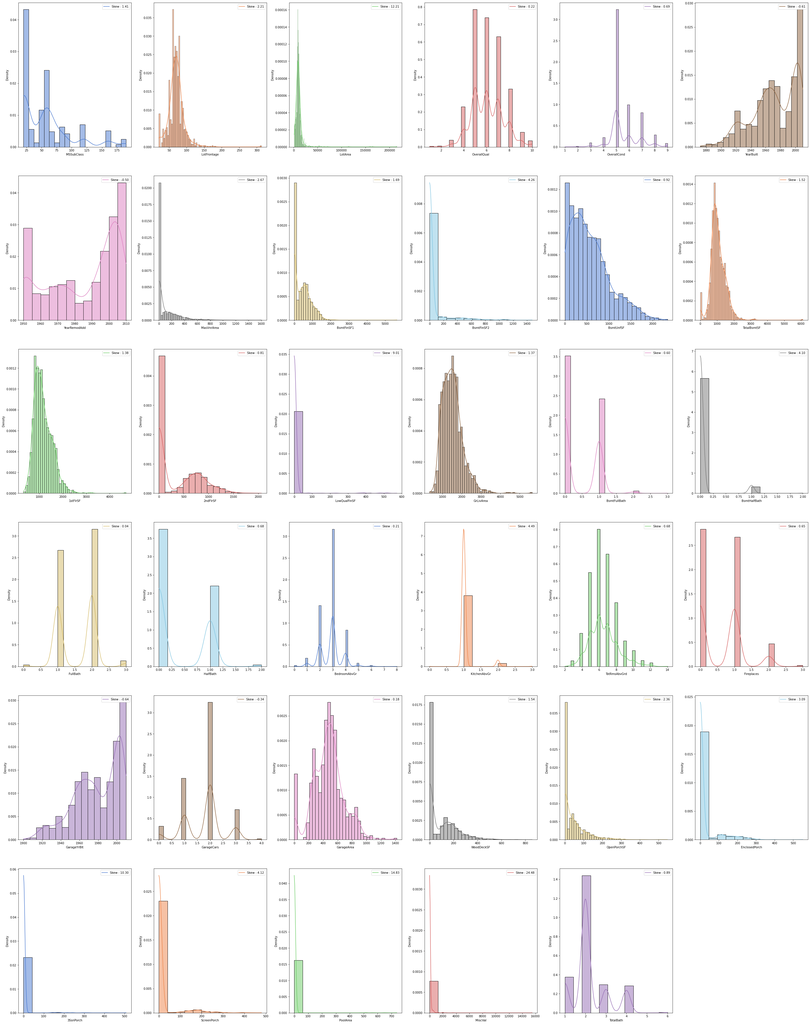

```python
numeric_cols,categorial_cols = get_num_cat_cols(X)
multiplot3(data= X,features = numeric_cols,plottype= "histplot",y=None,colorize=False,figsize = (15,15))
```

It can be seen that there are biases in some of the graphs for example in GrLiveArea in linear regression we want the distribution to be as normal as possible so we will reduce these biases by logging the values, in addition there is a need to normalize the values.

In fact most of the features have positive skew.

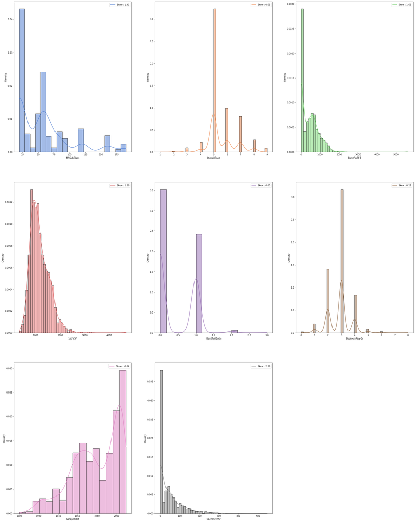

```python
lst = numeric_cols[::4]
multiplot3(data= X,features = lst ,plottype= "histplot",y=None,colorize=False,figsize = (10,10))
```

## Skewed Data:

[figure not shown]

[More About Skewed Data](https://towardsdatascience.com/skewed-data-a-problem-to-your-statistical-model-9a6b5bb74e37)

```python
for feature in numeric_cols:
    X[feature] = np.log1p(X[feature])
y = np.log1p(y)
```

### Standard Scalar:

StandardScaler removes the mean and scales the data to unit variance. The scaling shrinks the range of the feature values.**However, the outliers have an influence when computing the empirical mean and standard deviation.**

### Min-Max Scaler:

MinMaxScaler rescales the data set such that all feature values are in the range [0, 1]. MinMaxScaler are very sensitive to the presence of outliers.

### Robust Scaler:

the centering and scaling statistics of RobustScaler is based on percentiles and are therefore not influenced by a few number of very large marginal outliers.

[Numerical Data Scaling Methods](https://machinelearningmastery.com/standardscaler-and-minmaxscaler-transforms-in-python/)

[Compare the effect of different scalers on data with outliers](https://scikit-learn.org/stable/auto_examples/preprocessing/plot_all_scaling.html#sphx-glr-auto-examples-preprocessing-plot-all-scaling-py)  
According to the above and according to the visibility of the graphs, I will select: Min-Max Scaler  
This is because in linear regression I do not want to predict negative values for apartment prices.

```
standard scaler
```

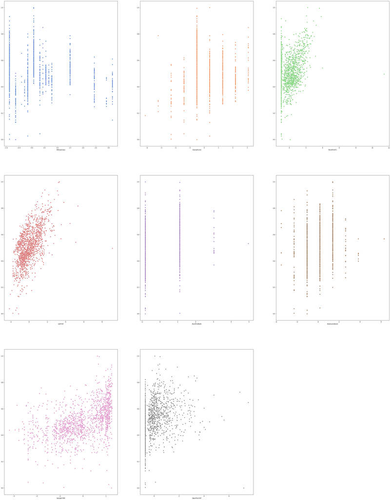

```
MinMax scaler
```

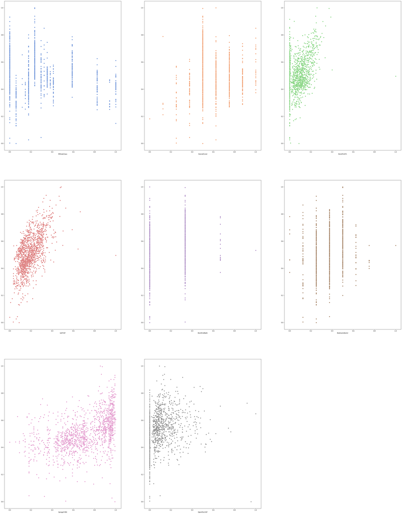

```
Robust scaler
```

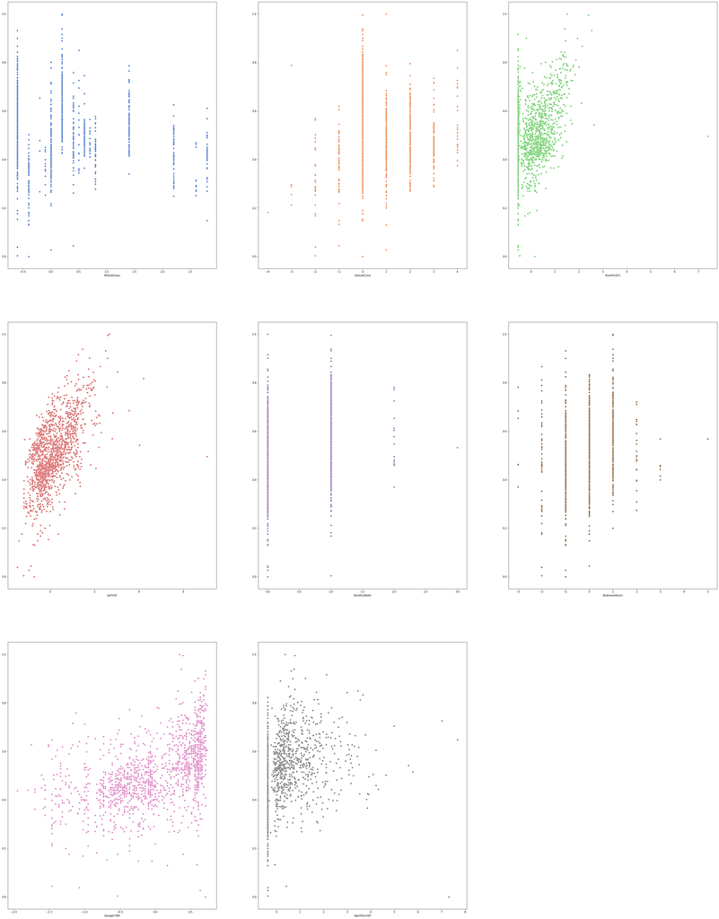

```python
def show_scale(df_encoded,target,cols,typeScale = 'standard'):
    X_stand = df_encoded.copy()
    X_stand.columns = X_stand.columns.astype(str)
    dict_scale = {'standard':StandardScaler().fit_transform(X_stand),
                  'MinMax': MinMaxScaler().fit_transform(X_stand),
                  'Robust': RobustScaler(quantile_range=(25, 75)).fit_transform(X_stand),
#                   'normalizer': Normalizer().fit_transform(X_stand)
#                   'MaxAbs': MaxAbsScaler().fit_transform(X_stand),
#                   'yeo':PowerTransformer(method="yeo-johnson").fit_transform(X_stand),
#                   'uniform': QuantileTransformer(output_distribution="uniform").fit_transform(X_stand),
#                   'normal':QuantileTransformer(output_distribution="normal").fit_transform(X_stand),
                  }
    scale = dict_scale[typeScale]
    dataset = pd.DataFrame(scale,columns = list(X_stand.columns))
    y =  minmax_scale(target)
    print(f'{typeScale} scaler')
    multiplot3(data= dataset,features = cols,plottype= "scatterplot",y=y,colorize=False,figsize = (15,15))
    print("\n")

y_stand = y.copy()
X = df_train_enc.drop("SalePrice", axis=1)
# print("stadard scalar")
show_scale(df_train_enc,y_stand,numeric_cols[::4],typeScale = 'standard')
# print("minmax scalar")
show_scale(df_train_enc,y_stand,numeric_cols[::4],typeScale = 'MinMax')
# print("robust scalar")
show_scale(df_train_enc,y_stand,numeric_cols[::4],typeScale = 'Robust')

# print("maxabs scalar")
# show_scale(df_train_enc,y_stand,numeric_cols[::4],typeScale = 'MaxAbs')
# print("yeo scalar")
# show_scale(df_train_enc,y_stand,numeric_cols[::4],typeScale = 'yeo')
# print("uniform scalar")
# show_scale(df_train_enc,y_stand,numeric_cols[::4],typeScale = 'uniform')
# # print("box-cox scalar")
# # show_scale(df_train_enc,y_stand,numeric_cols[::4],typeScale = 'box-cox')
# print("normalizer scalar")
# show_scale(df_train_enc,y_stand,numeric_cols[::4],typeScale = 'normalizer')
# print("normal scalar")
# show_scale(df_train_enc,y_stand,numeric_cols[::4],typeScale = 'normal')
```

```python
def show_scaler_and_RMSE(X_train, t_train, X_val, t_val, scalers):
    '''assuming X_train,X_val allready encoded'''
    score_df = pd.DataFrame(columns=['scaler_name', 'split', 'RMSE'])
    X_train.columns = X_train.columns.astype(str)
    X_val.columns = X_val.columns.astype(str)
    for scaler_name, scaler in scalers.items():

        model_pipe = pipeline.make_pipeline(scaler, linear_model.SGDRegressor(random_state=1))
        model_pipe.fit(X_train, t_train)

        y_train = model_pipe.predict(X_train)
        y_val = model_pipe.predict(X_val)

        score_df.loc[len(score_df)] = [scaler_name, 'train', sqrt(metrics.mean_squared_error(t_train, y_train))]
        score_df.loc[len(score_df)] = [scaler_name, 'val', sqrt(metrics.mean_squared_error(t_val, y_val))]


    # fig = sns.barplot(x=score_df['scaler_name'], y=score_df['RMSE'],data=score_df)
    # display(fig)
    fig = px.bar(score_df, x='scaler_name', y='RMSE', color='split', barmode='group')
    fig.show()
```

```python
X_train, X_val, t_train, t_val = model_selection.train_test_split(X, y_stand, test_size=0.3, random_state=1)
show_scaler_and_RMSE(X_train, t_train, X_val, t_val, {"MinMax": preprocessing.MinMaxScaler(), "Standard": preprocessing.StandardScaler()})
```

[interactive chart not shown]

**I'm done with the tedious part- now I'll start researching the data.**

# 6. EDA- Exploratory data analysis:

[figure not shown]

```python
report = ProfileReport(df_train, title="House Profiling Report", explorative=True)
```

```python
report.to_file('profile_report.html')
report
```

[output not shown]

# 7. Training-Time:

[figure not shown]

## 7.1 CV-cross validation:

We can use CV (Cross-Validation) instead of breaking the data to train-validation splits.  
When we use CV, we have better predictions of the test results.  
It is similar to splitting the data, but we make sure that our split won't affect our result (we try a few possible splits).  
We can use 2 CV:

1. **KFold**
2. **LPO** (Leave P out)

We will use **KFold** when we want speed.  
We will use **LPO** when we want to be more precise and better predict the test score.  
[More About](https://scikit-learn.org/stable/modules/cross_validation.html)

```python
# calculate score and loss from cv (KFold or LPO) and display graphs
def get_cv_score_and_loss(X, t, model, transformer=None, k=None, p=None, show_score_loss_graphs=False, use_pbar=True):
    '''
    method that gets: data and model and
    returns: R2 score and MSE loss
    '''
    scores_losses_df = pd.DataFrame(columns=['fold_id', 'split', 'score', 'loss'])
    X.columns = X.columns.astype(str)
    if k is not None:
        cv = model_selection.KFold(n_splits=k, shuffle=True, random_state=1)
        length = cv.n_splits
    elif p is not None:
        cv = model_selection.LeavePOut(p)
        length = cv.get_n_splits(X)
    else:
        raise ValueError('you need to specify k or p in order for the cv to work')

    if use_pbar:
        pbar = tqdm(desc='Computing Models', total=length)

    for i, (train_ids, val_ids) in enumerate(cv.split(X)):
        X_train = X.loc[train_ids+1] # Create train X and t
        t_train = t.loc[train_ids+1]

        X_val = X.loc[val_ids+1] # Create valid X and t
        t_val = t.loc[val_ids+1]

        model.fit(X_train, t_train) # Fitting on the model

        y_train = model.predict(X_train) # Getting predictions
        y_val = model.predict(X_val)


        scores_losses_df.loc[len(scores_losses_df)] = [i, 'train', model.score(X_train, t_train), sqrt(metrics.mean_squared_error(t_train, y_train))]
        scores_losses_df.loc[len(scores_losses_df)] = [i, 'val', model.score(X_val, t_val), sqrt(metrics.mean_squared_error(t_val, y_val))]

        if use_pbar:
            pbar.update()

    if use_pbar:
        pbar.close()

    val_scores_losses_df = scores_losses_df[scores_losses_df['split']=='val']
    train_scores_losses_df = scores_losses_df[scores_losses_df['split']=='train']

    mean_val_score = val_scores_losses_df['score'].mean()
    mean_val_loss = val_scores_losses_df['loss'].mean()
    mean_train_score = train_scores_losses_df['score'].mean()
    mean_train_loss = train_scores_losses_df['loss'].mean()

    if show_score_loss_graphs:
        fig = px.line(scores_losses_df, x='fold_id', y='score', color='split', title=f'Mean Val Score: {mean_val_score:.2f}, Mean Train Score: {mean_train_score:.2f}')
        fig.show()
        fig = px.line(scores_losses_df, x='fold_id', y='loss', color='split', title=f'Mean Val Loss: {mean_val_loss:.2f}, Mean Train Loss: {mean_train_loss:.2f}')
        fig.show()

    return mean_val_score, mean_val_loss, mean_train_score, mean_train_loss



# Model For The Cross Validation
numerical_cols = X.select_dtypes(include=['int64', 'float64']).columns
categorical_cols = X.select_dtypes(include=['object', 'bool']).columns
ct = compose.ColumnTransformer([("standard", preprocessing.MinMaxScaler(), numerical_cols)], remainder='passthrough')
model_pipe = pipeline.make_pipeline(preprocessing.MinMaxScaler(), linear_model.SGDRegressor(random_state=1))
# check 10-fold CV
get_cv_score_and_loss(X, y, model_pipe, k=10, show_score_loss_graphs=True)
# check 5-fold CV
get_cv_score_and_loss(X, y, model_pipe, k=5, show_score_loss_graphs=True)
```

[interactive chart not shown]

```
(0.6825429348790275,
 0.22370663406241414,
 0.7518596729247271,
 0.19878658698973758)
```

## 7.2 Feature Selection:

We want to choose the best features for our house dataset.  
There is 3 methods of Feature Selection:

1. **Forward Feature Selection**
2. **Backward Feature Selection**
3. **Hybrid Feature Selection**

In **Forward Feature Selection** we start from zero features and add features until we reach the number of maximum features or until we reach the best score.  
In **Backward Feature Selection** we start from the full feature set and remove features until we reach the number of minimum features or until we reach the best score.  
In **Hybrid Feature Selection**, we start from zero features and add/remove features until we reach the best score.

I'll use Scikit-learn RFE that is based on the **Backward Feature Selection**.  
I'll specify the target number of features to find and the selector will stop when it will reach this number of features.  
[More About Feature selection](https://towardsdatascience.com/feature-selection-techniques-in-machine-learning-with-python-f24e7da3f36e)

```python
X_cp = df_train.copy()
X_cp = X_cp.drop("SalePrice", axis=1)
y_cp = df_train.SalePrice
```

```python
# Using ordinal encoder only for the feature selection to get same number of cols
numerical_cols = X_cp.select_dtypes(include=['int64', 'float64']).columns
categorical_cols = X_cp.select_dtypes(include=['object', 'bool']).columns
all_cols = categorical_cols.tolist() + numerical_cols.tolist()

ct_enc_std = compose.ColumnTransformer([("standard", preprocessing.MinMaxScaler(), numerical_cols),
("encoding",preprocessing.OrdinalEncoder(), categorical_cols)])

X_encoded = pd.DataFrame(ct_enc_std.fit_transform(X_cp, y_cp), columns=all_cols)

selector = RFECV(linear_model.SGDRegressor(random_state=1), cv=RepeatedKFold(n_splits=5, n_repeats=10, random_state=1),
                 scoring='neg_mean_squared_error').fit(X_encoded, y_cp)
display(X_encoded.loc[:, selector.support_])
X_best = X_encoded.loc[:, selector.support_]
best_cols = X_encoded.loc[:, selector.support_].columns

fig = go.Figure()
fig.add_trace(go.Scatter(x=[i for i in range(1, len(selector.grid_scores_) + 1)], y= np.sqrt(-1*selector.grid_scores_)))
fig.update_xaxes(title_text="Number of features selected")
fig.update_yaxes(title_text="Cross validation loss [RMSE]")
fig.show()
print(best_cols)
```

|  | MSZoning | Street | Alley | LotShape | Utilities | LotConfig | Neighborhood | Condition1 | Condition2 | BldgType | HouseStyle | RoofStyle | Exterior1st | Exterior2nd | ExterQual | ExterCond | Foundation | BsmtCond | BsmtExposure | BsmtFinType2 | Heating | HeatingQC | CentralAir | Electrical | KitchenQual | Functional | GarageFinish | GarageQual | PavedDrive | … |
| --- | --- | --- | --- | --- | --- | --- | --- | --- | --- | --- | --- | --- | --- | --- | --- | --- | --- | --- | --- | --- | --- | --- | --- | --- | --- | --- | --- | --- | --- | --- |
| 0 | 0.235294 | 0.150685 | 0.033420 | 0.666667 | 0.949275 | 0.883333 | 0.125089 | 0.000000 | 0.064212 | 0.140098 | 0.119780 | 0.413559 | 0.259231 | 0.333333 | 0.666667 | 0.5 | 0.375 | 0.500000 | 0.000000 | 0.50 | 0.386460 | 0.000000 | 0.111517 | 0.000000 | 0.0 | 0.0 | 0.6 | 0.592111 | 1.0 | … |
| 1 | 0.000000 | 0.202055 | 0.038795 | 0.555556 | 0.753623 | 0.433333 | 0.173281 | 0.000000 | 0.121575 | 0.206547 | 0.212942 | 0.000000 | 0.174830 | 0.000000 | 0.666667 | 0.0 | 0.375 | 0.333333 | 0.333333 | 0.50 | 0.324401 | 0.347725 | 0.000000 | 0.000000 | 0.0 | 0.0 | 0.2 | 0.607207 | 1.0 | … |
| 2 | 0.235294 | 0.160959 | 0.046507 | 0.666667 | 0.934783 | 0.866667 | 0.086109 | 0.000000 | 0.185788 | 0.150573 | 0.134465 | 0.419370 | 0.273549 | 0.333333 | 0.666667 | 0.5 | 0.375 | 0.333333 | 0.333333 | 0.50 | 0.428773 | 0.000000 | 0.076782 | 0.000000 | 0.0 | 0.0 | 0.6 | 0.592111 | 1.0 | … |
| 3 | 0.294118 | 0.133562 | 0.038561 | 0.666667 | 0.311594 | 0.333333 | 0.038271 | 0.000000 | 0.231164 | 0.123732 | 0.143873 | 0.366102 | 0.260550 | 0.333333 | 0.333333 | 0.0 | 0.375 | 0.416667 | 0.333333 | 0.75 | 0.452750 | 0.000000 | 0.063985 | 0.492754 | 0.0 | 0.0 | 0.2 | 0.536307 | 1.0 | … |
| 4 | 0.235294 | 0.215753 | 0.060576 | 0.777778 | 0.927536 | 0.833333 | 0.116052 | 0.000000 | 0.209760 | 0.187398 | 0.186095 | 0.509927 | 0.351168 | 0.333333 | 0.666667 | 0.5 | 0.500 | 0.583333 | 0.333333 | 0.75 | 0.589563 | 0.224037 | 0.153565 | 0.000000 | 0.0 | 0.0 | 0.6 | 0.623181 | 1.0 | … |
| ... | ... | ... | ... | ... | ... | ... | ... | ... | ... | ... | ... | ... | ... | ... | ... | ... | ... | ... | ... | ... | ... | ... | ... | ... | ... | ... | ... | ... | ... | … |
| 1455 | 0.235294 | 0.140411 | 0.030929 | 0.555556 | 0.920290 | 0.833333 | 0.000000 | 0.000000 | 0.407962 | 0.155974 | 0.142038 | 0.336077 | 0.247362 | 0.000000 | 0.666667 | 0.5 | 0.375 | 0.416667 | 0.333333 | 0.50 | 0.324401 | 0.000000 | 0.073126 | 0.000000 | 0.0 | 0.0 | 0.2 | 0.505237 | 1.0 | … |
| 1456 | 0.000000 | 0.219178 | 0.055505 | 0.555556 | 0.768116 | 0.633333 | 0.139972 | 0.110583 | 0.252140 | 0.252373 | 0.399036 | 0.000000 | 0.327619 | 0.333333 | 0.666667 | 0.0 | 0.375 | 0.416667 | 0.666667 | 0.50 | 0.352609 | 0.407235 | 0.000000 | 0.000000 | 0.0 | 0.0 | 0.4 | 0.515061 | 1.0 | … |
| 1457 | 0.294118 | 0.154110 | 0.036187 | 0.666667 | 0.500000 | 0.933333 | 0.048724 | 0.000000 | 0.375428 | 0.188543 | 0.195961 | 0.557869 | 0.377920 | 0.000000 | 0.666667 | 0.0 | 0.500 | 0.583333 | 0.666667 | 0.25 | 0.177715 | 0.000000 | 0.109689 | 0.000000 | 0.0 | 0.0 | 0.2 | 0.845333 | 1.0 | … |
| 1458 | 0.000000 | 0.160959 | 0.039342 | 0.444444 | 0.565217 | 0.766667 | 0.008682 | 0.698100 | 0.000000 | 0.176432 | 0.170721 | 0.000000 | 0.140166 | 0.333333 | 0.333333 | 0.0 | 0.250 | 0.250000 | 0.000000 | 0.25 | 0.169252 | 0.427071 | 0.000000 | 0.202899 | 0.0 | 0.0 | 0.2 | 0.508157 | 1.0 | … |
| 1459 | 0.000000 | 0.184932 | 0.040370 | 0.444444 | 0.673913 | 0.250000 | 0.147059 | 0.196744 | 0.058219 | 0.205565 | 0.211565 | 0.000000 | 0.173700 | 0.333333 | 0.333333 | 0.5 | 0.375 | 0.333333 | 0.000000 | 0.25 | 0.194640 | 0.858810 | 0.124314 | 0.000000 | 0.0 | 0.0 | 0.2 | 0.563961 | 1.0 | … |

1460 rows × 44 columns

[interactive chart not shown]

```
Index(['MSZoning', 'Street', 'Alley', 'LotShape', 'Utilities', 'LotConfig',
       'Neighborhood', 'Condition1', 'Condition2', 'BldgType', 'HouseStyle',
       'RoofStyle', 'Exterior1st', 'Exterior2nd', 'ExterQual', 'ExterCond',
       'Foundation', 'BsmtCond', 'BsmtExposure', 'BsmtFinType2', 'Heating',
       'HeatingQC', 'CentralAir', 'Electrical', 'KitchenQual', 'Functional',
       'GarageFinish', 'GarageQual', 'PavedDrive', 'PoolQC', 'SaleType',
       'LotFrontage', 'LotArea', 'OverallCond', 'YearBuilt', 'BsmtFinSF2',
       '1stFlrSF', 'LowQualFinSF', 'HalfBath', 'KitchenAbvGr', 'TotRmsAbvGrd',
       'Fireplaces', 'OpenPorchSF', 'Location'],
      dtype='object')
```

## 7.3 Polynomial Degree:

[Understand Polynomial Degree](https://towardsdatascience.com/polynomial-regression-bbe8b9d97491)

```python
best_choice = df_train[best_cols]
best_choice
```

| Id | MSZoning | Street | Alley | LotShape | Utilities | LotConfig | Neighborhood | Condition1 | Condition2 | BldgType | HouseStyle | RoofStyle | Exterior1st | Exterior2nd | ExterQual | ExterCond | Foundation | BsmtCond | BsmtExposure | BsmtFinType2 | Heating | HeatingQC | CentralAir | Electrical | KitchenQual | Functional | GarageFinish | GarageQual | PavedDrive | … |
| --- | --- | --- | --- | --- | --- | --- | --- | --- | --- | --- | --- | --- | --- | --- | --- | --- | --- | --- | --- | --- | --- | --- | --- | --- | --- | --- | --- | --- | --- | --- |
| 1 | RL | Pave | None | Reg | AllPub | Inside | CollgCr | Norm | Norm | 1Fam | 2Story | Gable | VinylSd | VinylSd | Gd | TA | PConc | TA | No | Unf | GasA | Ex | Y | SBrkr | Gd | Typ | RFn | TA | Y | … |
| 2 | RL | Pave | None | Reg | AllPub | FR2 | Veenker | Feedr | Norm | 1Fam | 1Story | Gable | MetalSd | MetalSd | TA | TA | CBlock | TA | Gd | Unf | GasA | Ex | Y | SBrkr | TA | Typ | RFn | TA | Y | … |
| 3 | RL | Pave | None | IR1 | AllPub | Inside | CollgCr | Norm | Norm | 1Fam | 2Story | Gable | VinylSd | VinylSd | Gd | TA | PConc | TA | Mn | Unf | GasA | Ex | Y | SBrkr | Gd | Typ | RFn | TA | Y | … |
| 4 | RL | Pave | None | IR1 | AllPub | Corner | Crawfor | Norm | Norm | 1Fam | 2Story | Gable | Wd Sdng | Wd Shng | TA | TA | BrkTil | Gd | No | Unf | GasA | Gd | Y | SBrkr | Gd | Typ | Unf | TA | Y | … |
| 5 | RL | Pave | None | IR1 | AllPub | FR2 | NoRidge | Norm | Norm | 1Fam | 2Story | Gable | VinylSd | VinylSd | Gd | TA | PConc | TA | Av | Unf | GasA | Ex | Y | SBrkr | Gd | Typ | RFn | TA | Y | … |
| ... | ... | ... | ... | ... | ... | ... | ... | ... | ... | ... | ... | ... | ... | ... | ... | ... | ... | ... | ... | ... | ... | ... | ... | ... | ... | ... | ... | ... | ... | … |
| 1456 | RL | Pave | None | Reg | AllPub | Inside | Gilbert | Norm | Norm | 1Fam | 2Story | Gable | VinylSd | VinylSd | TA | TA | PConc | TA | No | Unf | GasA | Ex | Y | SBrkr | TA | Typ | RFn | TA | Y | … |
| 1457 | RL | Pave | None | Reg | AllPub | Inside | NWAmes | Norm | Norm | 1Fam | 1Story | Gable | Plywood | Plywood | TA | TA | CBlock | TA | No | Rec | GasA | TA | Y | SBrkr | TA | Min1 | Unf | TA | Y | … |
| 1458 | RL | Pave | None | Reg | AllPub | Inside | Crawfor | Norm | Norm | 1Fam | 2Story | Gable | CemntBd | CmentBd | Ex | Gd | Stone | Gd | No | Unf | GasA | Ex | Y | SBrkr | Gd | Typ | RFn | TA | Y | … |
| 1459 | RL | Pave | None | Reg | AllPub | Inside | NAmes | Norm | Norm | 1Fam | 1Story | Hip | MetalSd | MetalSd | TA | TA | CBlock | TA | Mn | Rec | GasA | Gd | Y | FuseA | Gd | Typ | Unf | TA | Y | … |
| 1460 | RL | Pave | None | Reg | AllPub | Inside | Edwards | Norm | Norm | 1Fam | 1Story | Gable | HdBoard | HdBoard | Gd | TA | CBlock | TA | No | LwQ | GasA | Gd | Y | SBrkr | TA | Typ | Fin | TA | Y | … |

1460 rows × 44 columns

```python
def show_degree_graphs_cv_train(X, t, model, k=None, p=None, max_degree=10):
    numerical_cols = X.select_dtypes(include=['int64', 'float64']).columns
    categorical_cols = X.select_dtypes(include=['object', 'bool']).columns

    val_train_score_loss_df = pd.DataFrame(columns=['degree', 'split', 'score', 'loss'])
    for i in tqdm(range(1, max_degree), desc='Poly Degree'):
        ct_enc_std_poly = ColumnTransformer([
            ("encoding", OneHotEncoder(sparse=False, handle_unknown='ignore'), categorical_cols),
            ("standard_poly", make_pipeline(PolynomialFeatures(degree=i), MinMaxScaler()), numerical_cols)])
        model_pipe = make_pipeline(ct_enc_std_poly, model)
        val_score, val_loss, train_score, train_loss = get_cv_score_and_loss(X, t, model_pipe, transformer=ct, k=k, p=p, show_score_loss_graphs=False, use_pbar=False)
        val_train_score_loss_df.loc[len(val_train_score_loss_df)] = [i, 'train', train_score, train_loss]
        val_train_score_loss_df.loc[len(val_train_score_loss_df)] = [i, 'cv', val_score, val_loss]

    fig = px.line(val_train_score_loss_df, x='degree', y='score', color='split')
    fig.show()
    fig = px.line(val_train_score_loss_df, x='degree', y='loss', color='split')
    fig.show()
```

```python
show_degree_graphs_cv_train(best_choice, y_cp, SGDRegressor(random_state=1), k=5 ,max_degree=6)
```

[interactive chart not shown]

**As can be seen, degree 2 gives the best results - a polynomial degree 2 is chosen.**

## 7.4 Hyper-Parameters:

Choosing the correct hyperparameters for machine learning or deep learning models is one of the best ways to extract the last juice out of your models.

- what is hyper-parameters?
  - These are the parameters that cannot be estimated by the model from the given data. These parameters are used to estimate the model parameters. For example, the learning rate in deep neural networks.
- What is hyperparameter tuning ?
  - process of determining the right combination of hyperparameters that allows the model to maximize model performance.
- How do I choose hyper-parameters?
  1. Manual hyperparameter tuning: In this method, different combinations of hyperparameters are set (and experimented with) manually.
  2. Automated hyperparameter tuning: In this method, optimal hyperparameters are found using an algorithm that automates and optimizes the process.
- The Hyper-Parameters I'll try to change: learning_rate
  - note: if I'll choose regularization method - I'll try to find the best penalty (count as hyper-parameter).

[More About Hyper-Parameters](https://neptune.ai/blog/hyperparameter-tuning-in-python-a-complete-guide-2020)  
[LR_finder](https://fastai1.fast.ai/callbacks.lr_finder.html)  
[eta0 on SGDregressor](https://scikit-learn.org/stable/modules/generated/sklearn.linear_model.SGDRegressor.html)

```python
def best_lr(x,t,num_iter = 1000):
    scores = pd.DataFrame(columns=['lr', "val_score", "val_loss", "train_score", "train_loss"])
    lr = 0.0001
    for i in range(num_iter):
        selector = SGDRegressor(eta0=lr, learning_rate="constant",random_state=1 ).fit(x, t)
        mean_val_score, mean_val_loss, mean_train_score, mean_train_loss = get_cv_score_and_loss(x, t, selector, k=10, show_score_loss_graphs=False, use_pbar=False)
        # The process converges
        if mean_val_loss < 0:
            break
        #add row to our scores df
        scores.loc[len(scores)] = [lr, mean_val_score, mean_val_loss, mean_train_score, mean_train_loss]
        lr += 0.0001
    print(f'finish')
    #PLOTTING
    fig = go.Figure()
    fig.update_xaxes(title_text="Learning Rate")
    fig.add_trace(go.Scatter(x=scores["lr"], y=scores["val_score"]))
    fig.update_yaxes(title_text="CV score")
    fig.show()
    #extract max-value score to choose best learning rate
    max_score_val = scores["val_score"].max()
    row_best = scores[scores["val_score"] == max_score_val]
    chosen_lr = row_best["lr"].to_numpy()[0]
    return chosen_lr, max_score_val

categorical_cols = best_choice.select_dtypes(include=['object', 'bool']).columns
numerical_cols = best_choice.select_dtypes(include=['int64', 'float64']).columns
all_cols = categorical_cols.tolist() + numerical_cols.tolist()
ct_learning_rate = ColumnTransformer([
    ("encoding", OneHotEncoder(sparse=False, handle_unknown='error',drop='first'), categorical_cols),
    ("standard", MinMaxScaler(), numerical_cols)])
numerical_cols
X_encoded = pd.DataFrame(ct_learning_rate.fit_transform(best_choice, y_cp))

X_encoded.index = best_choice.index

chosen_lr,best_score = best_lr(X_encoded,y_cp )
print("Best learning rate = {}".format(chosen_lr))
```

```
finish
```

[interactive chart not shown]

```
Best learning rate = 0.00030000000000000003
```

## 7.5 Regularization:

**I am trying to find out which regularization method is best for the model among the types of regularizations - l2, l1, elasticNet.**  
[More About Regularization](https://towardsdatascience.com/regularization-in-machine-learning-76441ddcf99a)

```python
# train with random search and get best parameters

distributions = dict(alpha=uniform(loc=0, scale=1), penalty=['l2', 'l1', 'elasticnet'])
rs_model = RandomizedSearchCV(SGDRegressor(eta0=chosen_lr,learning_rate="constant"), distributions, random_state=1).fit(X_encoded, y_cp)
print('Accuracy score for classification:')
print('rs_model', rs_model.best_score_)
print('best params', rs_model.best_params_)
```

```
Accuracy score for classification:
rs_model 0.8080714275993637
best params {'alpha': 0.8463109166860171, 'penalty': 'l1'}
```

# 8. Build Final Model:

- note- I'll not forget to train the model about the whole data.

```python
print(f'SUM UP:\n#Best features = {len(best_cols)}\nDegree of polynomial features = 2\nLearning_rate ={chosen_lr}\nRegularization method ={rs_model.best_params_["penalty"]}\nalpha = {rs_model.best_params_["alpha"]}' )
```

```
SUM UP:
#Best features = 44
Degree of polynomial features = 2
Learning_rate =0.00030000000000000003
Regularization method =l1
alpha = 0.8463109166860171
```

```python
X_final_train = best_choice.copy()
# X_final_train = df_train[['TotalBath','Location']].copy()

t = y_cp.copy()
X_final_train
```

| Id | MSZoning | Street | Alley | LotShape | Utilities | LotConfig | Neighborhood | Condition1 | Condition2 | BldgType | HouseStyle | RoofStyle | Exterior1st | Exterior2nd | ExterQual | ExterCond | Foundation | BsmtCond | BsmtExposure | BsmtFinType2 | Heating | HeatingQC | CentralAir | Electrical | KitchenQual | Functional | GarageFinish | GarageQual | PavedDrive | … |
| --- | --- | --- | --- | --- | --- | --- | --- | --- | --- | --- | --- | --- | --- | --- | --- | --- | --- | --- | --- | --- | --- | --- | --- | --- | --- | --- | --- | --- | --- | --- |
| 1 | RL | Pave | None | Reg | AllPub | Inside | CollgCr | Norm | Norm | 1Fam | 2Story | Gable | VinylSd | VinylSd | Gd | TA | PConc | TA | No | Unf | GasA | Ex | Y | SBrkr | Gd | Typ | RFn | TA | Y | … |
| 2 | RL | Pave | None | Reg | AllPub | FR2 | Veenker | Feedr | Norm | 1Fam | 1Story | Gable | MetalSd | MetalSd | TA | TA | CBlock | TA | Gd | Unf | GasA | Ex | Y | SBrkr | TA | Typ | RFn | TA | Y | … |
| 3 | RL | Pave | None | IR1 | AllPub | Inside | CollgCr | Norm | Norm | 1Fam | 2Story | Gable | VinylSd | VinylSd | Gd | TA | PConc | TA | Mn | Unf | GasA | Ex | Y | SBrkr | Gd | Typ | RFn | TA | Y | … |
| 4 | RL | Pave | None | IR1 | AllPub | Corner | Crawfor | Norm | Norm | 1Fam | 2Story | Gable | Wd Sdng | Wd Shng | TA | TA | BrkTil | Gd | No | Unf | GasA | Gd | Y | SBrkr | Gd | Typ | Unf | TA | Y | … |
| 5 | RL | Pave | None | IR1 | AllPub | FR2 | NoRidge | Norm | Norm | 1Fam | 2Story | Gable | VinylSd | VinylSd | Gd | TA | PConc | TA | Av | Unf | GasA | Ex | Y | SBrkr | Gd | Typ | RFn | TA | Y | … |
| ... | ... | ... | ... | ... | ... | ... | ... | ... | ... | ... | ... | ... | ... | ... | ... | ... | ... | ... | ... | ... | ... | ... | ... | ... | ... | ... | ... | ... | ... | … |
| 1456 | RL | Pave | None | Reg | AllPub | Inside | Gilbert | Norm | Norm | 1Fam | 2Story | Gable | VinylSd | VinylSd | TA | TA | PConc | TA | No | Unf | GasA | Ex | Y | SBrkr | TA | Typ | RFn | TA | Y | … |
| 1457 | RL | Pave | None | Reg | AllPub | Inside | NWAmes | Norm | Norm | 1Fam | 1Story | Gable | Plywood | Plywood | TA | TA | CBlock | TA | No | Rec | GasA | TA | Y | SBrkr | TA | Min1 | Unf | TA | Y | … |
| 1458 | RL | Pave | None | Reg | AllPub | Inside | Crawfor | Norm | Norm | 1Fam | 2Story | Gable | CemntBd | CmentBd | Ex | Gd | Stone | Gd | No | Unf | GasA | Ex | Y | SBrkr | Gd | Typ | RFn | TA | Y | … |
| 1459 | RL | Pave | None | Reg | AllPub | Inside | NAmes | Norm | Norm | 1Fam | 1Story | Hip | MetalSd | MetalSd | TA | TA | CBlock | TA | Mn | Rec | GasA | Gd | Y | FuseA | Gd | Typ | Unf | TA | Y | … |
| 1460 | RL | Pave | None | Reg | AllPub | Inside | Edwards | Norm | Norm | 1Fam | 1Story | Gable | HdBoard | HdBoard | Gd | TA | CBlock | TA | No | LwQ | GasA | Gd | Y | SBrkr | TA | Typ | Fin | TA | Y | … |

1460 rows × 44 columns

```python
#preprocessing
categorical_cols = X_final_train.select_dtypes(include=['object', 'bool']).columns
numerical_cols = X_final_train.select_dtypes(include=['int64', 'float64']).columns
ct_final = ColumnTransformer([
    ("encoding", OneHotEncoder(sparse=False, handle_unknown='ignore'), categorical_cols),
    ("standard", make_pipeline(PolynomialFeatures(degree=2), MinMaxScaler()), numerical_cols)])
#create the model
model_pipe = make_pipeline(ct_final, SGDRegressor(penalty=rs_model.best_params_["penalty"], random_state=1, alpha=rs_model.best_params_["alpha"], eta0=chosen_lr, learning_rate="constant"))
model_pipe.fit(X_final_train,t)
#train the model
y_train_final = model_pipe.predict(X_final_train)
#error calculate
rmse = metrics.mean_squared_error(t, y_train_final, squared=False)
print(f"Final rmse = {rmse}")
```

```
Final rmse = 29153.12529136721
```

# 9. Prediction:

now we can use in df_test that we loaded in section 3(Load Data).

```python
#Feature selection
X_test = df_test[best_cols]
# X_test = df_test[['TotalBath','Location']].copy()
display(X_test)
#prediction
y_pred = model_pipe.predict(X_test)
#submission
submission = pd.DataFrame({
        "Id": test_id,
        "SalePrice": y_pred
    })
submission.to_csv('submission.csv', index=False)
```

[output not shown]

# 10. Submissions:

> Note: My first submission was the best of my other submissions

[figure not shown]

## My Position on the Leaderboard

[figure not shown]

# Work Summary:

The mission was very long but eventually came to an end!

[figure not shown]

For use at sweetviz:  
Install-  
update plotly and pandas_profiling version  
`!pip install sweetviz`

In Code-  
`import sweetviz as sw`

`house_report = sw.analyze(data_train)`  
`house_report.show_notebook(layout='vertical')`